# Preliminary aquatic challenge synthesis

2023-10-02

## Inventory of submissions

To start we can look at what the submissions look like, number of teams, general characteristics, which variables and sites were forecasted etc. Some of this might go in the methods and/or results.

```r
# read the metadata from the google sheet
googlesheets4::gs4_deauth()
model_meta <- googlesheets4::read_sheet("https://docs.google.com/spreadsheets/d/1oC7_w63wSCXNiHs1IK8AFGr0MG-NdjDAjwkfjvRZW-I/edit?usp=sharing", sheet = 'descriptions') |>
  mutate(unc_driver = ifelse(uses_NOAA == 1, 1, 0)) |>
  na.omit(variable)
```

What and where was forecasted?

```r
scores <- arrow::open_dataset(file.path(here::here(),"scores")) |>
  filter(model_id %in% model_meta$model_id)

distinct_submissions <- scores |>
  distinct(site_id, variable, model_id) |>
  collect()

head(distinct_submissions)
```

```
## # A tibble: 6 × 3
##   variable    model_id                   site_id
##   <chr>       <chr>                      <chr>
## 1 temperature GLEON_JRabaey_temp_physics BARC
## 2 temperature GLEON_JRabaey_temp_physics ARIK
## 3 temperature GLEON_JRabaey_temp_physics BIGC
## 4 temperature GLEON_JRabaey_temp_physics BLDE
## 5 temperature GLEON_JRabaey_temp_physics BLWA
## 6 temperature GLEON_JRabaey_temp_physics CARI
```

How many sites did each model forecast?

```r
distinct_submissions |>
  group_by(model_id) |>
  distinct(site_id) |>
  summarise(site_n = n()) |>
  group_by(site_n) |>
  summarise(n_models = n())
```

```
## # A tibble: 5 × 2
##   site_n n_models
##    <int>    <int>
## 1      6        1
## 2      7       13
## 3     10        1
## 4     33        1
## 5     34       20
```

How many variables did each model forecast?

```r
distinct_submissions |>
  group_by(model_id) |>
  distinct(variable) |>
  summarise(variable_n = n()) |>
  group_by(variable_n) |>
  summarise(n_models = n())
```

```
## # A tibble: 3 × 2
##   variable_n n_models
##        <int>    <int>
## 1          1       20
## 2          2        1
## 3          3       15
```

When assessing model performance we can look at raw scores (CRPS) or skill - score relative to a null model. We can use the climatology null model to calculate the skill scores for each model

```r
lake_sites <- c('BARC', 'CRAM', 'LIRO', 'PRLA', 'PRPO', 'SUGG', 'TOOK')

# extract just the climatology scores
climatology_lake <- scores |>
  filter(model_id == 'climatology',
         site_id %in% lake_sites,
         variable == 'temperature') |>
  collect() |>
  select(reference_datetime, datetime, crps, logs, site_id, model_id, variable) |>
  arrange(reference_datetime, datetime, site_id) |>
  pivot_wider(values_from = c(crps, logs),
              names_from = model_id)

# get the model scores
lake_scores <- scores |>
  filter(site_id %in% lake_sites,
         model_id %in% model_meta$model_id,
         variable == 'temperature') |>
  collect()

# Calculate the skill scores
lake_skill <- lake_scores |>
  filter(model_id != 'climatology') |>
  select(reference_datetime, datetime, crps, logs, site_id, model_id, variable) |>
  full_join(climatology_lake, by = c('reference_datetime', 'datetime', 'site_id', 'variable')) |>

  # calcaulte the skill relative to climatology (- is bad, + is good)
  mutate(skill_crps = crps_climatology - crps,
         skill_logs = logs_climatology - logs,
         horizon = as.numeric(as_date(datetime) - as_date(reference_datetime))) |>
  # consistent forecast period
  filter(horizon <= 30,
         horizon >= 1) |>
  arrange(reference_datetime, site_id, datetime, model_id)
```

### Model structure

Looking at the structure of the forecast models. Are they dynamic, include initial conditions, update parameters or use data assimilation?

```r
# Aspects of DA
# do the forecasts contain initial conditions?
model_meta |>
  summarise(initial_cond = sum(initial_cond, na.rm = T),
            # do the forecast models update parameters?
            updates_parameters = sum(updates_parameters, na.rm = T),
            # is the forecast 'dynamic'?
            dynamic = sum(dynamic, na.rm = T))
```

```
## # A tibble: 1 × 3
##   initial_cond updates_parameters dynamic
##          <dbl>              <dbl>   <dbl>
## 1           21                 20      22
```

How does model structure relate to performance?

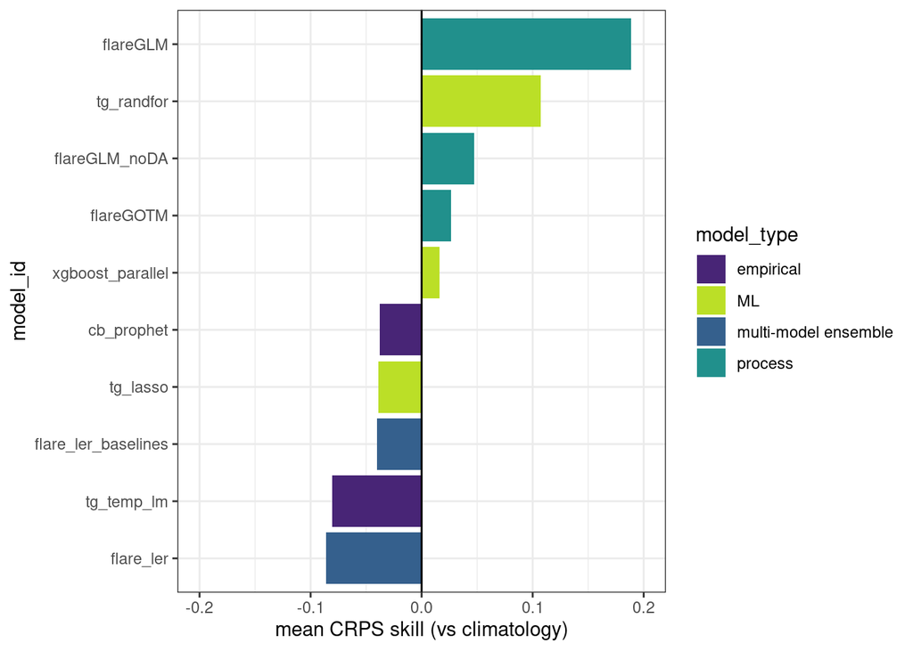

```r
lake_skill |>
  group_by(model_id) |>
  summarise(mean_skill = mean(skill_crps, na.rm = T)) |>
  ungroup() |>
  slice_max(mean_skill, n= 10, na_rm = T) |>
  left_join(model_meta) |>
  mutate(model_id = fct_reorder(model_id, mean_skill)) |>
  ggplot(aes(x=mean_skill,
             y = model_id,
             fill = model_type)) +
  geom_bar(stat = 'identity') +
  tidytext::scale_y_reordered() +
  labs(y='model_id', x = 'mean CRPS skill (vs climatology)') +
  geom_vline(xintercept = 0) +
  scale_fill_manual(values = cols_modeltype) +
  scale_x_continuous(limits = c(-0.2,0.2),
                     breaks = c(-0.2,-0.1,0,0.1,0.2))+
  theme_bw()
```

But the best models (and model types) are not consistent across sites. Looking at the individual sites:

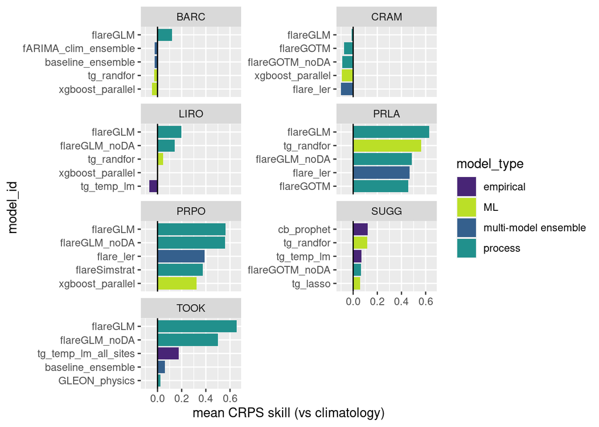

```r
lake_skill |>
  group_by(model_id, site_id) |>
  summarise(mean_crps = mean(skill_crps, na.rm = T)) |>
  group_by(site_id) |>
  slice_max(mean_crps, n = 5, na_rm = T) |>
  mutate(model_id = fct_reorder(model_id, desc(mean_crps))) |>
  left_join(model_meta) |>
  ggplot(aes(x=mean_crps,
             y = reorder_within(x = model_id, within = site_id, by = mean_crps),
             fill = model_type)) +
  geom_bar(stat = 'identity') +
  scale_y_reordered() +
  scale_fill_manual(values = cols_modeltype) +
  facet_wrap(~site_id, scales = 'free_y', ncol = 2) +
  labs(y='model_id', x = 'mean CRPS skill (vs climatology)') +
  geom_vline(xintercept = 0)
```

We can also look at how this varies across the forecast horizon. For one site it might look like this:

```
## Defaulting to continuous.
```

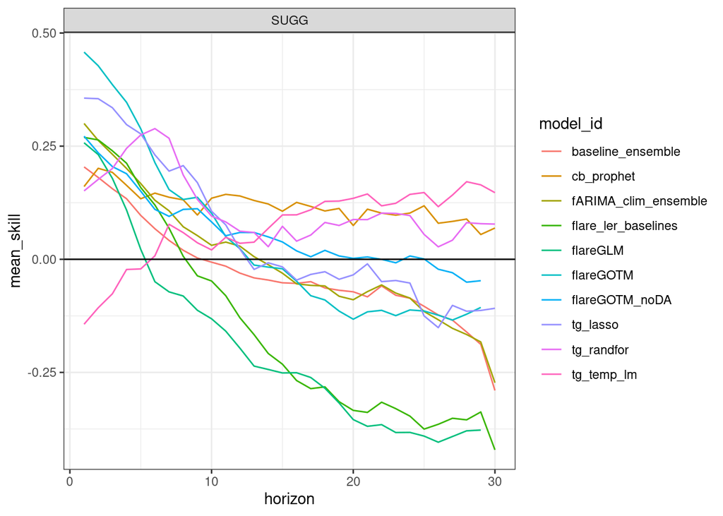

```r
# first find the top models
SUGG_mods <-
  lake_skill |>
  filter(site_id == 'SUGG') |>
  mutate(horizon = datetime - as_date(reference_datetime)) |>
  group_by(model_id) |>
  summarise(mean_skill = mean(skill_crps, na.rm = T)) |>
  slice_max(mean_skill, n = 10, na_rm = T)


lake_skill |>
  filter(site_id == 'SUGG',
         model_id %in% SUGG_mods$model_id) |>
  mutate(horizon = datetime - as_date(reference_datetime)) |>
  group_by(model_id, horizon, site_id) |>
  summarise(mean_skill = mean(skill_crps, na.rm = T)) |>
  left_join(model_meta)  |>

  ggplot(aes(x=horizon, y=mean_skill, colour = model_id)) +
  geom_line() +
  facet_wrap(~site_id) +
  geom_hline(yintercept = 0) +
  theme_bw()
```

Generally forecast skill reduces across the horizon, with more models beating climatology null at shorter horizons and only a few at longer horizons. For SUGG example, cb_prophet and tg_randfor are the only ones to be skillful across the full horizon.

Another way to think about this would be to look at generally how do model types do across all site? Or how do all our models do at forecasting particular site? Are some sites more “forecastable” than others?

We can look at the top 10 models on average to see how they do overall and at each site.

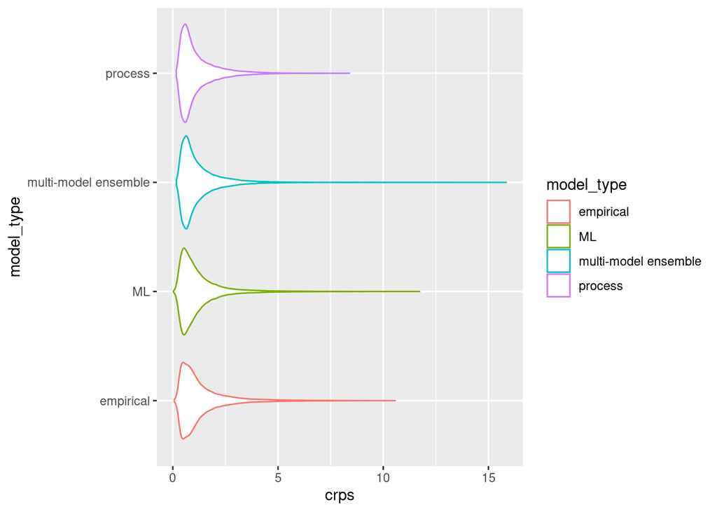

```r
# top 10 average models
top_mods <- lake_skill |>
  group_by(model_id) |>
  summarise(mean_crps = mean(skill_crps, na.rm = T)) |>
  ungroup() |>
  slice_max(mean_crps, n = 10, na_rm = T) |>
  distinct(model_id)

lake_scores |>
  left_join(model_meta, by = 'model_id') |>
  filter(model_id %in% top_mods$model_id) |>
  ggplot(aes(x=crps, y = model_type)) +
  geom_violin(aes(colour = model_type))
```

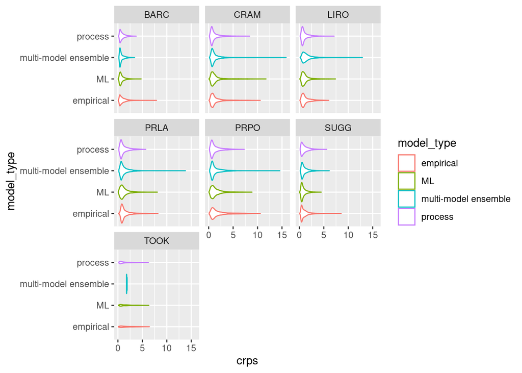

```r
lake_scores |>
  left_join(model_meta, by = 'model_id') |>
  filter(model_id %in% top_mods$model_id) |>
  # group_by(model_type, site_id) |>
  # summarise(mean_crps = mean(crps, na.rm = T)) |>
  # mutate(model_type = fct_reorder(model_type, desc(mean_crps))) |>
  ggplot(aes(x=crps, y = model_type)) +
  geom_violin(aes(colour = model_type)) +
  facet_wrap(~site_id)
```

### Uncertainty representation

The uncertainty each model represents might be an interesting characteristic to investigate how skill varies?

```r
# types of uncertainty represented
# Number of models that contain each type
model_meta |>
  summarise(across(contains('unc'), ~ sum(.x, na.rm = T)))
```

```
## # A tibble: 1 × 4
##   unc_parameter unc_process unc_initial unc_driver
##           <dbl>       <dbl>       <dbl>      <dbl>
## 1            13          14          10         30
```

Driver uncertainty is the most common type included and initial condition uncertainty the least common. Most forecasts only include one type of uncertainty.

```r
# How many sources are represented in each model?
model_meta |>
  select(model_id, contains('unc_')) |>
  mutate(unc_n = rowSums(pick(where(is.numeric)))) |>
  group_by(unc_n) |>
  summarise(n = n())
```

```
## # A tibble: 5 × 2
##   unc_n     n
##   <dbl> <int>
## 1     0     1
## 2     1    22
## 3     2     5
## 4     3     1
## 5     4     8
```

Most forecasts only represent one source of uncertainty (usually driver), but a good number also include multiple sources of uncertainty.

### NOAA weather covariates

I’ve also looked at what weather covariates are used in each model from those available from NOAA. No model uses covaraite drivers other than NOAA weather forecasts.

```r
NOAA_vars <- c('air_temperature',
               'air_pressure',
               'relative_humidity',
               'surface_downwelling_longwave_flux_in_air',
               'surface_downwelling_shortwave_flux_in_air',
               'precipitation_flux',
               'eastward_wind',
               'northward_wind')

NOAA_summary <- model_meta |>
  select(model_id)


for (i in 1:length(NOAA_vars)) {
  detect_var <- NOAA_vars[i]

  NOAA_summary <-
    NOAA_summary |>
    mutate(detect_var = str_detect(model_meta$NOAA_var, detect_var))

  colnames(NOAA_summary)[1 + i] <- detect_var
}
```

Summarising the driver variables to see how many models use each of the variables. Air temperature being the most common driver variable followed by short wave radiation.

```r
NOAA_summary |>
  select(-model_id) |>
  summarise_all(~sum(.x, na.rm = T)) |>
  pivot_longer(cols = everything(),
               names_to = 'NOAA_vars',
               values_to = 'n_models') |>
  arrange(desc(n_models))
```

```
## # A tibble: 8 × 2
##   NOAA_vars                                 n_models
##   <chr>                                        <int>
## 1 air_temperature                                 26
## 2 surface_downwelling_shortwave_flux_in_air       18
## 3 relative_humidity                               14
## 4 precipitation_flux                              12
## 5 eastward_wind                                   11
## 6 air_pressure                                    10
## 7 surface_downwelling_longwave_flux_in_air        10
## 8 northward_wind                                   9
```

We also see that many models use just this single driver variable, with the next common to use all 8 (in many of the complex process models).

```r
NOAA_summary |>
  mutate(vars_n = rowSums(pick(where(is.logical)))) |>
  group_by(vars_n) |>
  summarise(n_models = n()) |>
  arrange(desc(n_models))
```

```
## # A tibble: 7 × 2
##   vars_n n_models
##    <dbl>    <int>
## 1      1       11
## 2      8        8
## 3      0        7
## 4      2        7
## 5      7        2
## 6      3        1
## 7      4        1
```

In addition to looking at how each of these models performs and looking at relationships with the driver variable and number of drivers used, I also started to think about how this relates to the performance of the NOAA forecasts themselves. Does the skill of the aquatic forecasts mirror the driver variables that are included in the model?

### NOAA forecast performance

```r
NOAA_scores <- arrow::open_dataset(file.path(here::here(),"scores")) |>
  filter(model_id == 'NOAA_daily',
         site_id %in% c('ARIK', 'BARC', 'BLDE'),
         variable %in% c('air_temperature', 'eastward_wind')) |>
  collect()

NOAA_scores |>
  mutate(horizon = as.numeric(datetime - as_date(reference_datetime))) |>
  filter(horizon <= 30) |>
  group_by(site_id, variable, horizon) |>
  summarise(crps = mean(crps, na.rm = T)) |>
  ggplot(aes(x=horizon, y=crps, colour = site_id)) +
  geom_line() +
  facet_wrap(~variable)
```

[output not shown]

## Things to think about

1. Are all models equally represented? To make them comparable.
2. Same with sites? Do we have the same number of days/models etc.?
3. What to do about models that don’t forecast all sites?